# Zotero group Safe_Edit_Test

Published

15 October 2026

This report shows the state of the Zotero group **Safe_Edit_Test** ([open the group in Zotero](https://www.zotero.org/groups/6719916)). It gives an overview of the literature in the group, and lists the items which should be corrected.

Each item in the lists can be opened in the Zotero **web** library or in the Zotero **app** on your computer, so that it can be corrected directly. Corrected items disappear from the lists the next time the report is updated. Some checks compare the items with [OpenAlex](https://openalex.org), an open catalogue of scholarly publications.

## Summary

| Status | Check | Items |
| --- | --- | --- |
| ● Please fix | Retracted publications | 1 |
| ● Please fix | DOI points to a different publication | 14 |
| ● Please fix | Items which are in the group more than once | 1 |
| ● OK | DOI field with an invalid DOI | 0 |
| ● Please fix | DOI field with a link or prefix instead of the DOI | 35 |
| ● Please check | ISSN not in the standard form | 43 |
| ● Please check | DOI in the wrong field | 45 |
| ● Please check | DOI not found in OpenAlex | 16 |
| ● Please check | Missing or unusual publication year | 16 |
| ● Please check | Empty journal, volume, issue or pages, found in OpenAlex | 55 |
| ● Please check | Language not given as a language code | 26 |
| ● Please check | Items without DOI, ISBN, ISSN or URL | 142 |
| ● Please check | Items without DOI, for which OpenAlex has one | 75 |
| ● OK | OpenAlex ID in Extra not valid | 0 |
| ● For information | Items without their OpenAlex ID in Extra | 505 |
| ● For information | Items without tags | 40 |

**Please fix**: these items contain errors. **Please check**: these items may need a correction. **For information**: no action needed unless the group uses this, e.g. tags.

## Items to fix

The lists are sorted by importance. Use the search field above a list to find an item. **web** opens the item in the Zotero web library, **app** in the Zotero app.

### Retracted publications

These publications have been retracted. Check whether they should still be cited, and mark or remove them in Zotero.

| Open in Zotero | Title | DOI |
| --- | --- | --- |
| <a href="https://www.zotero.org/groups/6719916/items/8DWWI6XZ" target="_blank">web</a> &middot; <a href="zotero://select/groups/6719916/items/8DWWI6XZ">app</a> | RETRACTED ARTICLE: Origin and cross-species transmission of bat coronaviruses in China | <a href="https://doi.org/10.1038/s41467-020-17687-3" target="_blank">10.1038/s41467-020-17687-3</a> |

### DOI points to a different publication

The DOI of these items leads to a publication with a different title or year. Usually the DOI is wrong: open the DOI to see where it leads, and correct it in Zotero. Differences of one year (e.g. published online before print) are not listed.

| Open in Zotero | Title in Zotero | Year in Zotero | The DOI leads to | Its year | DOI |
| --- | --- | --- | --- | --- | --- |
| <a href="https://www.zotero.org/groups/6719916/items/YXF2UWC7" target="_blank">web</a> &middot; <a href="zotero://select/groups/6719916/items/YXF2UWC7">app</a> | Wetland Pest and Disease Regulation. In: Finlayson C. et al. (eds) The Wetland Book. Springer, Dordrecht. | 2016 | Wetland Pest and Disease Regulation | 2016 | <a href="https://doi.org/10.1007/978-94-007-6172-8_228-2" target="_blank">10.1007/978-94-007-6172-8_228-2</a> |
| <a href="https://www.zotero.org/groups/6719916/items/CGUHZCUJ" target="_blank">web</a> &middot; <a href="zotero://select/groups/6719916/items/CGUHZCUJ">app</a> | Toward a new understanding of the links between poverty and illegal wildlife hunting: Poverty and Illegal Wildlife Hunting | 2016 | Toward a new understanding of the links between poverty and illegal wildlife hunting | 2015 | <a href="https://doi.org/10.1111/cobi.12622" target="_blank">10.1111/cobi.12622</a> |
| <a href="https://www.zotero.org/groups/6719916/items/SUI2K23S" target="_blank">web</a> &middot; <a href="zotero://select/groups/6719916/items/SUI2K23S">app</a> | The nature relatedness scale: Linking individuals' connection with nature to environmental concern and behavior | 2009 | The Nature Relatedness Scale | 2008 | <a href="https://doi.org/10.1177/0013916508318748" target="_blank">10.1177/0013916508318748</a> |
| <a href="https://www.zotero.org/groups/6719916/items/CSQM64RD" target="_blank">web</a> &middot; <a href="zotero://select/groups/6719916/items/CSQM64RD">app</a> | Subsistence, substitutability and sustainability in consumption | 2017 | Subsistence, Substitutability and Sustainability in Consumption | 2015 | <a href="https://doi.org/10.1007/s10640-015-9976-z" target="_blank">10.1007/s10640-015-9976-z</a> |
| <a href="https://www.zotero.org/groups/6719916/items/MLH9V6M6" target="_blank">web</a> &middot; <a href="zotero://select/groups/6719916/items/MLH9V6M6">app</a> | Public Health Implications of Changing Rodent Importation Patterns - United States, 1999-2013 | 2017 | Public Health Implications of Changing Rodent Importation Patterns - United States, 1999-2013 | 2015 | <a href="https://doi.org/10.1111/tbed.12396" target="_blank">10.1111/tbed.12396</a> |
| <a href="https://www.zotero.org/groups/6719916/items/QFZD2GSL" target="_blank">web</a> &middot; <a href="zotero://select/groups/6719916/items/QFZD2GSL">app</a> | Predicting Pathogen Introduction: West Nile Virus Spread to Galápagos: Predicting West Nile Virus Spread | 2006 | Predicting Pathogen Introduction: West Nile Virus Spread to Galápagos | 2006 | <a href="https://doi.org/10.1111/j.1523-1739.2006.00423.x" target="_blank">10.1111/j.1523-1739.2006.00423.x</a> |
| <a href="https://www.zotero.org/groups/6719916/items/8DWWI6XZ" target="_blank">web</a> &middot; <a href="zotero://select/groups/6719916/items/8DWWI6XZ">app</a> | Origin and cross-species transmission of bat coronaviruses in China | 2020 | RETRACTED ARTICLE: Origin and cross-species transmission of bat coronaviruses in China | 2020 | <a href="https://doi.org/10.1038/s41467-020-17687-3" target="_blank">10.1038/s41467-020-17687-3</a> |
| <a href="https://www.zotero.org/groups/6719916/items/2M784U8B" target="_blank">web</a> &middot; <a href="zotero://select/groups/6719916/items/2M784U8B">app</a> | Novel, panzootic and hybrid genotypes of amphibian chytridiomycosis associated with the bullfrog trade: CHYTRID GENOTYPES AND THE BULLFROG TRADE | 2012 | Novel, panzootic and hybrid genotypes of amphibian chytridiomycosis associated with the bullfrog trade | 2012 | <a href="https://doi.org/10.1111/j.1365-294x.2012.05710.x" target="_blank">10.1111/j.1365-294x.2012.05710.x</a> |
| <a href="https://www.zotero.org/groups/6719916/items/IWQ3CJBD" target="_blank">web</a> &middot; <a href="zotero://select/groups/6719916/items/IWQ3CJBD">app</a> | Managing the endogenous risk of disease outbreaks | 2015 | Managing the endogenous risk of disease outbreaks with non-constant background risk | 2014 | <a href="https://doi.org/10.1016/j.jedc.2014.09.014" target="_blank">10.1016/j.jedc.2014.09.014</a> |
| <a href="https://www.zotero.org/groups/6719916/items/LHEN29HW" target="_blank">web</a> &middot; <a href="zotero://select/groups/6719916/items/LHEN29HW">app</a> | Invasion of bluetongue and other orbivirus infections into Europe: the role of biological and climatic processes | 2008 | Las invasiones de lengua azul y otras infecciones por orbivirus en Europa: papel de los procesos biológicos y climáticos | 2008 | <a href="https://doi.org/10.20506/rst.27.2.1801" target="_blank">10.20506/rst.27.2.1801</a> |

[output cut: 4 more lines]

### Items which are in the group more than once

These items are in the group more than once, with the same DOI, or with the same title, year and first author. Keep one copy and merge or delete the others, e.g. with *Duplicate Items* in the Zotero app.

| Open in Zotero | Title | Copies |
| --- | --- | --- |
| <a href="https://www.zotero.org/groups/6719916/items/YW7TCVPB" target="_blank">web</a> &middot; <a href="zotero://select/groups/6719916/items/YW7TCVPB">app</a><br><a href="https://www.zotero.org/group… | Transmissions to mice indicate that “new variant” CJD is caused by the BSE agent | 2 |

### DOI field with an invalid DOI

The DOI field of these items contains something which is not a valid DOI. Correct or remove it.

**✔ Nothing to fix.**

### DOI field with a link or prefix instead of the DOI

The DOI field of these items contains the DOI as a link (`https://doi.org/…`) or with a prefix (`DOI …`). Citation styles add the link themselves, so it would appear twice. Replace it with the DOI only.

| Open in Zotero | Title | Content of the DOI field | DOI |
| --- | --- | --- | --- |
| <a href="https://www.zotero.org/groups/6719916/items/6LR5VRQB" target="_blank">web</a> &middot; <a href="zotero://select/groups/6719916/items/6LR5VRQB">app</a> | Wildlife sinks: Quantifying the impact of illegal bird trade in street markets in Brazil | https://doi.org/10.1016/j.biocon.2012.02.009 | <a href="https://doi.org/10.1016/j.biocon.2012.02.009" target="_blank">10.1016/j.biocon.2012.02.009</a> |
| <a href="https://www.zotero.org/groups/6719916/items/KENVMMFY" target="_blank">web</a> &middot; <a href="zotero://select/groups/6719916/items/KENVMMFY">app</a> | Wildlife laundering through breeding farms: Illegal harvest, population declines and a means of regulating the trade of green pythons (Morelia viridis) from Indonesia | https://doi.org/10.1016/j.biocon.2011.10.002 | <a href="https://doi.org/10.1016/j.biocon.2011.10.002" target="_blank">10.1016/j.biocon.2011.10.002</a> |
| <a href="https://www.zotero.org/groups/6719916/items/YXF2UWC7" target="_blank">web</a> &middot; <a href="zotero://select/groups/6719916/items/YXF2UWC7">app</a> | Wetland Pest and Disease Regulation. In: Finlayson C. et al. (eds) The Wetland Book. Springer, Dordrecht. | https://doi.org/10.1007/978-94-007-6172-8_228-2 | <a href="https://doi.org/10.1007/978-94-007-6172-8_228-2" target="_blank">10.1007/978-94-007-6172-8_228-2</a> |
| <a href="https://www.zotero.org/groups/6719916/items/ANNQUCKS" target="_blank">web</a> &middot; <a href="zotero://select/groups/6719916/items/ANNQUCKS">app</a> | Under what circumstances can wildlife farming benefit species conservation? | https://doi.org/10.1016/j.gecco.2016.03.007 | <a href="https://doi.org/10.1016/j.gecco.2016.03.007" target="_blank">10.1016/j.gecco.2016.03.007</a> |
| <a href="https://www.zotero.org/groups/6719916/items/NV5X3ES6" target="_blank">web</a> &middot; <a href="zotero://select/groups/6719916/items/NV5X3ES6">app</a> | Towards informed and multi-faceted wildlife trade interventions | https://doi.org/10.1016/j.gecco.2014.11.010 | <a href="https://doi.org/10.1016/j.gecco.2014.11.010" target="_blank">10.1016/j.gecco.2014.11.010</a> |
| <a href="https://www.zotero.org/groups/6719916/items/VZXMJTNB" target="_blank">web</a> &middot; <a href="zotero://select/groups/6719916/items/VZXMJTNB">app</a> | The role of protected areas in supporting human health: a call to broaden the assessment of conservation outcomes | https://doi.org/10.1016/j.cosust.2017.08.005 | <a href="https://doi.org/10.1016/j.cosust.2017.08.005" target="_blank">10.1016/j.cosust.2017.08.005</a> |
| <a href="https://www.zotero.org/groups/6719916/items/SGA6WVXF" target="_blank">web</a> &middot; <a href="zotero://select/groups/6719916/items/SGA6WVXF">app</a> | The gravity of wildlife trade | https://doi.org/10.1016/j.biocon.2017.11.007 | <a href="https://doi.org/10.1016/j.biocon.2017.11.007" target="_blank">10.1016/j.biocon.2017.11.007</a> |
| <a href="https://www.zotero.org/groups/6719916/items/8VVVEDS8" target="_blank">web</a> &middot; <a href="zotero://select/groups/6719916/items/8VVVEDS8">app</a> | The economics of wildlife farming and endangered species conservation | https://doi.org/10.1016/j.ecolecon.2006.07.007 | <a href="https://doi.org/10.1016/j.ecolecon.2006.07.007" target="_blank">10.1016/j.ecolecon.2006.07.007</a> |
| <a href="https://www.zotero.org/groups/6719916/items/RZBBDPB7" target="_blank">web</a> &middot; <a href="zotero://select/groups/6719916/items/RZBBDPB7">app</a> | The conservation impact of commercial wildlife farming of porcupines in Vietnam | https://doi.org/10.1016/j.biocon.2010.07.030 | <a href="https://doi.org/10.1016/j.biocon.2010.07.030" target="_blank">10.1016/j.biocon.2010.07.030</a> |
| <a href="https://www.zotero.org/groups/6719916/items/LXR2W2N7" target="_blank">web</a> &middot; <a href="zotero://select/groups/6719916/items/LXR2W2N7">app</a> | The Berlin principles on one health – Bridging global health and conservation | https://doi.org/10.1016/j.scitotenv.2020.142919 | <a href="https://doi.org/10.1016/j.scitotenv.2020.142919" target="_blank">10.1016/j.scitotenv.2020.142919</a> |

[output cut: 25 more lines]

### ISSN not in the standard form

The ISSN field of these items is not in the standard form `1234-567X` (several separated by “,”), or contains something which is not a valid ISSN, e.g. an ISBN.

| Open in Zotero | Title | Content of the ISSN field | Standard form | Not a valid ISSN |
| --- | --- | --- | --- | --- |
| <a href="https://www.zotero.org/groups/6719916/items/JS5RNLWT" target="_blank">web</a> &middot; <a href="zotero://select/groups/6719916/items/JS5RNLWT">app</a> | What can we predict about viral evolution and emergence? | 18796257 | 1879-6257 | NA |
| <a href="https://www.zotero.org/groups/6719916/items/2HMU5IXQ" target="_blank">web</a> &middot; <a href="zotero://select/groups/6719916/items/2HMU5IXQ">app</a> | Variant Creutzfeldt-Jakob disease | 01406736 | 0140-6736 | NA |
| <a href="https://www.zotero.org/groups/6719916/items/CGUHZCUJ" target="_blank">web</a> &middot; <a href="zotero://select/groups/6719916/items/CGUHZCUJ">app</a> | Toward a new understanding of the links between poverty and illegal wildlife hunting: Poverty and Illegal Wildlife Hunting | 08888892 | 0888-8892 | NA |
| <a href="https://www.zotero.org/groups/6719916/items/CWA323BB" target="_blank">web</a> &middot; <a href="zotero://select/groups/6719916/items/CWA323BB">app</a> | Tick-borne encephalitis virus in cows and unpasteurized cow milk from Norway | 18631959 | 1863-1959 | NA |
| <a href="https://www.zotero.org/groups/6719916/items/28L9K32X" target="_blank">web</a> &middot; <a href="zotero://select/groups/6719916/items/28L9K32X">app</a> | The European Union summary report on antimicrobial resistance in zoonotic and indicator bacteria from humans, animals and food in 2017 | 18314732, 18314732 | 1831-4732 | NA |
| <a href="https://www.zotero.org/groups/6719916/items/89FWHQS2" target="_blank">web</a> &middot; <a href="zotero://select/groups/6719916/items/89FWHQS2">app</a> | The epidemiology of bluetongue | 01479571 | 0147-9571 | NA |
| <a href="https://www.zotero.org/groups/6719916/items/TJJVKZ8W" target="_blank">web</a> &middot; <a href="zotero://select/groups/6719916/items/TJJVKZ8W">app</a> | The Economic and Public Health Imperatives Around Making Potential Coronavirus Disease–2019 Treatments Available and Affordable | 10983015 | 1098-3015 | NA |
| <a href="https://www.zotero.org/groups/6719916/items/MLH9V6M6" target="_blank">web</a> &middot; <a href="zotero://select/groups/6719916/items/MLH9V6M6">app</a> | Public Health Implications of Changing Rodent Importation Patterns - United States, 1999-2013 | 18651674 | 1865-1674 | NA |
| <a href="https://www.zotero.org/groups/6719916/items/6PKZIKMV" target="_blank">web</a> &middot; <a href="zotero://select/groups/6719916/items/6PKZIKMV">app</a> | ProMED global monitoring of emerging diseases: design for a demonstration program | 01688510 | 0168-8510 | NA |
| <a href="https://www.zotero.org/groups/6719916/items/U9VTPCCB" target="_blank">web</a> &middot; <a href="zotero://select/groups/6719916/items/U9VTPCCB">app</a> | Prediction and prevention of the next pandemic zoonosis | 01406736 | 0140-6736 | NA |

[output cut: 33 more lines]

### DOI in the wrong field

These items have no DOI in the DOI field, but a DOI in the URL or Extra field. Copy the DOI into the DOI field.

| Open in Zotero | Title | DOI in URL | DOI in Extra |
| --- | --- | --- | --- |
| <a href="https://www.zotero.org/groups/6719916/items/ELSSV8WA" target="_blank">web</a> &middot; <a href="zotero://select/groups/6719916/items/ELSSV8WA">app</a> | Zoonoses |  | <a href="https://doi.org/10.1016/b978-012373944-5.00213-3" target="_blank">10.1016/b978-012373944-5.00213-3</a> |
| <a href="https://www.zotero.org/groups/6719916/items/6VU9YC67" target="_blank">web</a> &middot; <a href="zotero://select/groups/6719916/items/6VU9YC67">app</a> | Wildlife and Emerging Zoonotic Diseases: The Biology, Circumstances and Consequences of Cross-Species Transmission | <a href="https://doi.org/10.1007/978-3-540-70962-6" target="_blank">10.1007/978-3-540-70962-6</a> | <a href="https://doi.org/10.1007/978-3-540-70962-6" target="_blank">10.1007/978-3-540-70962-6</a> |
| <a href="https://www.zotero.org/groups/6719916/items/8T7QN55L" target="_blank">web</a> &middot; <a href="zotero://select/groups/6719916/items/8T7QN55L">app</a> | The Inclusive Cost of Pandemic Influenza Risk |  | <a href="https://doi.org/10.3386/w22137" target="_blank">10.3386/w22137</a> |
| <a href="https://www.zotero.org/groups/6719916/items/UDZGPVKH" target="_blank">web</a> &middot; <a href="zotero://select/groups/6719916/items/UDZGPVKH">app</a> | The ‘Anthropocene’ (2002) | <a href="https://doi.org/10.1007/978-3-030-82202-6_4" target="_blank">10.1007/978-3-030-82202-6_4</a> | <a href="https://doi.org/10.1007/978-3-030-82202-6_4" target="_blank">10.1007/978-3-030-82202-6_4</a> |
| <a href="https://www.zotero.org/groups/6719916/items/EISNM8K4" target="_blank">web</a> &middot; <a href="zotero://select/groups/6719916/items/EISNM8K4">app</a> | Sporadic influenza A virus infections of miscellaneous mammal species | <a href="https://doi.org/10.1002/9781118924341.ch23" target="_blank">10.1002/9781118924341.ch23</a> | <a href="https://doi.org/10.1002/9781118924341.ch23" target="_blank">10.1002/9781118924341.ch23</a> |
| <a href="https://www.zotero.org/groups/6719916/items/4QQ3UQ79" target="_blank">web</a> &middot; <a href="zotero://select/groups/6719916/items/4QQ3UQ79">app</a> | How is COVID-19 affecting the fisheries and aquaculture food systems |  | <a href="https://doi.org/10.4060/ca8637en" target="_blank">10.4060/ca8637en</a> |
| <a href="https://www.zotero.org/groups/6719916/items/3J22C69U" target="_blank">web</a> &middot; <a href="zotero://select/groups/6719916/items/3J22C69U">app</a> | Healthy Wetlands, Healthy People: Mosquito Borne Disease | <a href="https://doi.org/10.1007/978-94-017-9609-5_6" target="_blank">10.1007/978-94-017-9609-5_6</a> | <a href="https://doi.org/10.1007/978-94-017-9609-5_6" target="_blank">10.1007/978-94-017-9609-5_6</a> |
| <a href="https://www.zotero.org/groups/6719916/items/2K2237AE" target="_blank">web</a> &middot; <a href="zotero://select/groups/6719916/items/2K2237AE">app</a> | Emerging Viral Zoonoses from Wildlife Associated with Animal-Based Food Systems: Risks and Opportunities | <a href="https://doi.org/10.1007/978-3-319-24442-6_2" target="_blank">10.1007/978-3-319-24442-6_2</a> | <a href="https://doi.org/10.1007/978-3-319-24442-6_2" target="_blank">10.1007/978-3-319-24442-6_2</a> |
| <a href="https://www.zotero.org/groups/6719916/items/MJZF8ELP" target="_blank">web</a> &middot; <a href="zotero://select/groups/6719916/items/MJZF8ELP">app</a> | Climate Change and Human Health Scenario in South and Southeast Asia |  | <a href="https://doi.org/10.1007/978-3-319-23684-1" target="_blank">10.1007/978-3-319-23684-1</a> |
| <a href="https://www.zotero.org/groups/6719916/items/7IK7MEP3" target="_blank">web</a> &middot; <a href="zotero://select/groups/6719916/items/7IK7MEP3">app</a> | Chapter 2.1 Status and Trends –Drivers of Change |  | <a href="https://doi.org/10.5281/zenodo.3831881" target="_blank">10.5281/zenodo.3831881</a> |

[output cut: 35 more lines]

### DOI not found in OpenAlex

These DOIs were not found in OpenAlex. The DOI may be wrong: open it to check. If it leads to the right publication, the publication is simply not (yet) in OpenAlex and nothing needs to be done.

| Open in Zotero | Title | DOI |
| --- | --- | --- |
| <a href="https://www.zotero.org/groups/6719916/items/AQ5X6D9U" target="_blank">web</a> &middot; <a href="zotero://select/groups/6719916/items/AQ5X6D9U">app</a> | Vicuña conservation and poverty alleviation? Andean communities and international fibre markets | <a href="https://doi.org/10.18352/ijc.139" target="_blank">10.18352/ijc.139</a> |
| <a href="https://www.zotero.org/groups/6719916/items/RB6HYF8A" target="_blank">web</a> &middot; <a href="zotero://select/groups/6719916/items/RB6HYF8A">app</a> | SARS-CoV-2 infection, neuropathogenesis and transmission among deer mice: Implications for reverse zoonosis to New World rodents | <a href="https://doi.org/10.1101/2020.08.07.241810" target="_blank">10.1101/2020.08.07.241810</a> |
| <a href="https://www.zotero.org/groups/6719916/items/CT55Y6NF" target="_blank">web</a> &middot; <a href="zotero://select/groups/6719916/items/CT55Y6NF">app</a> | Post COVID-19: a solution scan of options for preventing future zoonotic epidemics | <a href="https://doi.org/10.17605/osf.io/5jx3g" target="_blank">10.17605/osf.io/5jx3g</a> |
| <a href="https://www.zotero.org/groups/6719916/items/4LTXRVFH" target="_blank">web</a> &middot; <a href="zotero://select/groups/6719916/items/4LTXRVFH">app</a> | No evidence of coronaviruses or other potentially zoonotic viruses in Sunda pangolins (<i>Manis javanica</i>) entering the wildlife trade via Malaysia | <a href="https://doi.org/10.1101/2020.06.19.158717" target="_blank">10.1101/2020.06.19.158717</a> |
| <a href="https://www.zotero.org/groups/6719916/items/49WN8732" target="_blank">web</a> &middot; <a href="zotero://select/groups/6719916/items/49WN8732">app</a> | Middle East respiratory syndrome coronavirus quasi-species that include homologues of human isolates revealed through whole genome analysis and virus cultured from dromedary camels in Saudi Arabia | <a href="https://doi.org/10.1128/mbio.01146-1429" target="_blank">10.1128/mbio.01146-1429</a> |
| <a href="https://www.zotero.org/groups/6719916/items/RINHF3IU" target="_blank">web</a> &middot; <a href="zotero://select/groups/6719916/items/RINHF3IU">app</a> | Jumping back and forth: anthropozoonotic and zoonotic transmission of SARS-CoV-2 on mink farms | <a href="https://doi.org/10.1101/2020.09.01.277152" target="_blank">10.1101/2020.09.01.277152</a> |
| <a href="https://www.zotero.org/groups/6719916/items/NXR6RMZZ" target="_blank">web</a> &middot; <a href="zotero://select/groups/6719916/items/NXR6RMZZ">app</a> | Forest fragmentation as cause of bacterial transmission among primates, humans, and livestock, Uganda | <a href="https://doi.org/10.3201/eid1409.071196" target="_blank">10.3201/eid1409.071196</a> |
| <a href="https://www.zotero.org/groups/6719916/items/J68G28BG" target="_blank">web</a> &middot; <a href="zotero://select/groups/6719916/items/J68G28BG">app</a> | Climate change will drive novel cross-species viral transmission | <a href="https://doi.org/10.1101/2020.01.24.918755" target="_blank">10.1101/2020.01.24.918755</a> |
| <a href="https://www.zotero.org/groups/6719916/items/ZJZ8NQDJ" target="_blank">web</a> &middot; <a href="zotero://select/groups/6719916/items/ZJZ8NQDJ">app</a> | Accessibility and allocation of public parks and gardens during COVID-19 social distancing in England and Wales | <a href="https://doi.org/10.1101/2020.05.11.20098269" target="_blank">10.1101/2020.05.11.20098269</a> |
| <a href="https://www.zotero.org/groups/6719916/items/7CX7I5TY" target="_blank">web</a> &middot; <a href="zotero://select/groups/6719916/items/7CX7I5TY">app</a> | Safe Edit test article F: a very long title to check that long values wrap and are shown in full in the approval dialog and in the app, without any truncation, horizontal scrolling or hidden parts, ev… | <a href="https://doi.org/10.5555/safe-edit.f" target="_blank">10.5555/safe-edit.f</a> |

[output cut: 6 more lines]

### Missing or unusual publication year

These items have no date, a date from which no year could be read, or a year in the future. Correct the date in Zotero.

| Open in Zotero | Title | Date | Problem | Date in OpenAlex |
| --- | --- | --- | --- | --- |
| <a href="https://www.zotero.org/groups/6719916/items/YKS3UHT5" target="_blank">web</a> &middot; <a href="zotero://select/groups/6719916/items/YKS3UHT5">app</a> | Zoonoses |  | No date | NA |
| <a href="https://www.zotero.org/groups/6719916/items/QHKE8EB9" target="_blank">web</a> &middot; <a href="zotero://select/groups/6719916/items/QHKE8EB9">app</a> | wildlife product |  | No date | NA |
| <a href="https://www.zotero.org/groups/6719916/items/BTEVWVPM" target="_blank">web</a> &middot; <a href="zotero://select/groups/6719916/items/BTEVWVPM">app</a> | Understanding the WTO Agreement on Sanitary and Phytosanitary Measures |  | No date | NA |
| <a href="https://www.zotero.org/groups/6719916/items/R9ARM6K8" target="_blank">web</a> &middot; <a href="zotero://select/groups/6719916/items/R9ARM6K8">app</a> | Traditional, Complementary and Integrative Medicine |  | No date | NA |
| <a href="https://www.zotero.org/groups/6719916/items/IM8VKH9K" target="_blank">web</a> &middot; <a href="zotero://select/groups/6719916/items/IM8VKH9K">app</a> | Snakes and ladders: a review of ball python production in West Africa for the global pet market |  | No date | NA |
| <a href="https://www.zotero.org/groups/6719916/items/WWRJ39PA" target="_blank">web</a> &middot; <a href="zotero://select/groups/6719916/items/WWRJ39PA">app</a> | Sanitation |  | No date | NA |
| <a href="https://www.zotero.org/groups/6719916/items/NHMT24BU" target="_blank">web</a> &middot; <a href="zotero://select/groups/6719916/items/NHMT24BU">app</a> | Public-private partnerships (PPPs) |  | No date | NA |
| <a href="https://www.zotero.org/groups/6719916/items/LHMFS6U4" target="_blank">web</a> &middot; <a href="zotero://select/groups/6719916/items/LHMFS6U4">app</a> | Patents |  | No date | NA |
| <a href="https://www.zotero.org/groups/6719916/items/YKBAETXN" target="_blank">web</a> &middot; <a href="zotero://select/groups/6719916/items/YKBAETXN">app</a> | IUCN DEFINITIONS |  | No date | NA |
| <a href="https://www.zotero.org/groups/6719916/items/FE9Z52IY" target="_blank">web</a> &middot; <a href="zotero://select/groups/6719916/items/FE9Z52IY">app</a> | Infectious disease threats: from rebound to resilience | In review | Year not recognised | NA |

[output cut: 6 more lines]

### Empty journal, volume, issue or pages, found in OpenAlex

These journal articles have an empty journal, volume, issue or pages field, and OpenAlex has the value for their DOI. Check it with the DOI and fill in the field.

| Open in Zotero | Title | Field | Value in OpenAlex | DOI |
| --- | --- | --- | --- | --- |
| <a href="https://www.zotero.org/groups/6719916/items/J66HCHRH" target="_blank">web</a> &middot; <a href="zotero://select/groups/6719916/items/J66HCHRH">app</a> | A familial cluster of pneumonia associated with the 2019 novel coronavirus indicating person-to-person transmission: a study of a family cluster | Volume | 395 | <a href="https://doi.org/10.1016/s0140-6736(20)30154-9" target="_blank">10.1016/s0140-6736(20)30154-9</a> |
| <a href="https://www.zotero.org/groups/6719916/items/J66HCHRH" target="_blank">web</a> &middot; <a href="zotero://select/groups/6719916/items/J66HCHRH">app</a> | A familial cluster of pneumonia associated with the 2019 novel coronavirus indicating person-to-person transmission: a study of a family cluster | Issue | 10223 | <a href="https://doi.org/10.1016/s0140-6736(20)30154-9" target="_blank">10.1016/s0140-6736(20)30154-9</a> |
| <a href="https://www.zotero.org/groups/6719916/items/J66HCHRH" target="_blank">web</a> &middot; <a href="zotero://select/groups/6719916/items/J66HCHRH">app</a> | A familial cluster of pneumonia associated with the 2019 novel coronavirus indicating person-to-person transmission: a study of a family cluster | Pages | 514-523 | <a href="https://doi.org/10.1016/s0140-6736(20)30154-9" target="_blank">10.1016/s0140-6736(20)30154-9</a> |
| <a href="https://www.zotero.org/groups/6719916/items/QKDUFMWP" target="_blank">web</a> &middot; <a href="zotero://select/groups/6719916/items/QKDUFMWP">app</a> | A pneumonia outbreak associated with a new coronavirus of probable bat origin | Volume | 579 | <a href="https://doi.org/10.1038/s41586-020-2012-7" target="_blank">10.1038/s41586-020-2012-7</a> |
| <a href="https://www.zotero.org/groups/6719916/items/QKDUFMWP" target="_blank">web</a> &middot; <a href="zotero://select/groups/6719916/items/QKDUFMWP">app</a> | A pneumonia outbreak associated with a new coronavirus of probable bat origin | Issue | 7798 | <a href="https://doi.org/10.1038/s41586-020-2012-7" target="_blank">10.1038/s41586-020-2012-7</a> |
| <a href="https://www.zotero.org/groups/6719916/items/QKDUFMWP" target="_blank">web</a> &middot; <a href="zotero://select/groups/6719916/items/QKDUFMWP">app</a> | A pneumonia outbreak associated with a new coronavirus of probable bat origin | Pages | 270-273 | <a href="https://doi.org/10.1038/s41586-020-2012-7" target="_blank">10.1038/s41586-020-2012-7</a> |
| <a href="https://www.zotero.org/groups/6719916/items/JZ8Q6RBK" target="_blank">web</a> &middot; <a href="zotero://select/groups/6719916/items/JZ8Q6RBK">app</a> | Bat conservation and zoonotic disease risk: a research agenda to prevent misguided persecution in the aftermath of COVID-19 | Pages | 303-307 | <a href="https://doi.org/10.1111/acv.12636" target="_blank">10.1111/acv.12636</a> |
| <a href="https://www.zotero.org/groups/6719916/items/FBW85EC3" target="_blank">web</a> &middot; <a href="zotero://select/groups/6719916/items/FBW85EC3">app</a> | Bats and COVID-19: villains or victims? | Issue | 3 | <a href="https://doi.org/10.1590/1676-0611-bn-2020-1055" target="_blank">10.1590/1676-0611-bn-2020-1055</a> |
| <a href="https://www.zotero.org/groups/6719916/items/QHWTQDWT" target="_blank">web</a> &middot; <a href="zotero://select/groups/6719916/items/QHWTQDWT">app</a> | Bats host major mammalian paramyxoviruses | Issue | 1 | <a href="https://doi.org/10.1038/ncomms1796" target="_blank">10.1038/ncomms1796</a> |
| <a href="https://www.zotero.org/groups/6719916/items/3ZDWNLPL" target="_blank">web</a> &middot; <a href="zotero://select/groups/6719916/items/3ZDWNLPL">app</a> | Biodiversity, drug discovery, and the future of global health: Introducing the biodiversity to biomedicine consortium, a call to action | Pages | 020304 | <a href="https://doi.org/10.7189/jogh.07.020304" target="_blank">10.7189/jogh.07.020304</a> |

[output cut: 75 more lines]

### Language not given as a language code

The language of these items is not given as a language code (`en`, `fr`, `en-US`), e.g. as `English` or `eng`. Citation styles only recognise the codes. Where the language was recognised, the code is shown; otherwise look up the code in the [ISO 639-1 list](https://en.wikipedia.org/wiki/List_of_ISO_639_language_codes).

| Open in Zotero | Title | Language | Language code |
| --- | --- | --- | --- |
| <a href="https://www.zotero.org/groups/6719916/items/3U4U24C5" target="_blank">web</a> &middot; <a href="zotero://select/groups/6719916/items/3U4U24C5">app</a> | Transmissions to mice indicate that 'new variant' CJD is caused by the BSE agent | eng | en |
| <a href="https://www.zotero.org/groups/6719916/items/3T8YX6EU" target="_blank">web</a> &middot; <a href="zotero://select/groups/6719916/items/3T8YX6EU">app</a> | Transmission dynamics and epidemiology of BSE in British cattle | eng | en |
| <a href="https://www.zotero.org/groups/6719916/items/7NITHGA3" target="_blank">web</a> &middot; <a href="zotero://select/groups/6719916/items/7NITHGA3">app</a> | The metapopulation dynamics of an infectious disease: tuberculosis in possums | eng | en |
| <a href="https://www.zotero.org/groups/6719916/items/TARC64SA" target="_blank">web</a> &middot; <a href="zotero://select/groups/6719916/items/TARC64SA">app</a> | The invasion, persistence and spread of infectious diseases within animal and plant communities | eng | en |
| <a href="https://www.zotero.org/groups/6719916/items/AD95HZQ4" target="_blank">web</a> &middot; <a href="zotero://select/groups/6719916/items/AD95HZQ4">app</a> | The internet and the global monitoring of emerging diseases: lessons from the first 10 years of ProMED-mail | eng | en |
| <a href="https://www.zotero.org/groups/6719916/items/4H29GIKW" target="_blank">web</a> &middot; <a href="zotero://select/groups/6719916/items/4H29GIKW">app</a> | The impact of community organization on vector-borne pathogens | eng | en |
| <a href="https://www.zotero.org/groups/6719916/items/28L9K32X" target="_blank">web</a> &middot; <a href="zotero://select/groups/6719916/items/28L9K32X">app</a> | The European Union summary report on antimicrobial resistance in zoonotic and indicator bacteria from humans, animals and food in 2017 | eng | en |
| <a href="https://www.zotero.org/groups/6719916/items/9HZP2EPR" target="_blank">web</a> &middot; <a href="zotero://select/groups/6719916/items/9HZP2EPR">app</a> | The ecology of infectious disease: effects of host diversity and community composition on Lyme disease risk | eng | en |
| <a href="https://www.zotero.org/groups/6719916/items/58RDPQMV" target="_blank">web</a> &middot; <a href="zotero://select/groups/6719916/items/58RDPQMV">app</a> | Rabies in northeastern Europe--the threat from invasive raccoon dogs | eng | en |
| <a href="https://www.zotero.org/groups/6719916/items/VH26S7M6" target="_blank">web</a> &middot; <a href="zotero://select/groups/6719916/items/VH26S7M6">app</a> | ProMED mail | https://promedmail.org/ | NA |

[output cut: 16 more lines]

### Items without DOI, ISBN, ISSN or URL

Readers cannot easily find these items. Add a DOI, ISBN, ISSN or URL if one exists. Some items, e.g. personal communications, have none.

| Open in Zotero | Title | Type |
| --- | --- | --- |
| <a href="https://www.zotero.org/groups/6719916/items/YKS3UHT5" target="_blank">web</a> &middot; <a href="zotero://select/groups/6719916/items/YKS3UHT5">app</a> | Zoonoses | journal article |
| <a href="https://www.zotero.org/groups/6719916/items/ZSH9DLAE" target="_blank">web</a> &middot; <a href="zotero://select/groups/6719916/items/ZSH9DLAE">app</a> | Zero Draft of the Post-2020 Global Biodiversity Framework. Addendum. CBD/WG2020/2/3 | journal article |
| <a href="https://www.zotero.org/groups/6719916/items/ICNJ6FCB" target="_blank">web</a> &middot; <a href="zotero://select/groups/6719916/items/ICNJ6FCB">app</a> | World urbanization: trends and prospects | book section |
| <a href="https://www.zotero.org/groups/6719916/items/JLHLIMML" target="_blank">web</a> &middot; <a href="zotero://select/groups/6719916/items/JLHLIMML">app</a> | World Population Prospects 2019 | journal article |
| <a href="https://www.zotero.org/groups/6719916/items/7UVW95XV" target="_blank">web</a> &middot; <a href="zotero://select/groups/6719916/items/7UVW95XV">app</a> | Women at the core of the fight against COVID-19 crisis | report |
| <a href="https://www.zotero.org/groups/6719916/items/QHKE8EB9" target="_blank">web</a> &middot; <a href="zotero://select/groups/6719916/items/QHKE8EB9">app</a> | wildlife product | journal article |
| <a href="https://www.zotero.org/groups/6719916/items/9GXVWLD2" target="_blank">web</a> &middot; <a href="zotero://select/groups/6719916/items/9GXVWLD2">app</a> | Wildlife farming in Viet Nam: Southern Viet Nam’s wildlife farm survey report in a glance | journal article |
| <a href="https://www.zotero.org/groups/6719916/items/7LATZQVI" target="_blank">web</a> &middot; <a href="zotero://select/groups/6719916/items/7LATZQVI">app</a> | “What’s Driving the Wildlife Trade? A Review of Expert Opinion on Economic and Social Drivers of the Wildlife Trade and Trade Control Efforts in Cambodia, Indonesia, Lao PDR and Vietnam”. East Asia an… | journal article |
| <a href="https://www.zotero.org/groups/6719916/items/2MN6XZN2" target="_blank">web</a> &middot; <a href="zotero://select/groups/6719916/items/2MN6XZN2">app</a> | What is the Anthropocene? – current definition and status | journal article |
| <a href="https://www.zotero.org/groups/6719916/items/AJWBA7B6" target="_blank">web</a> &middot; <a href="zotero://select/groups/6719916/items/AJWBA7B6">app</a> | What is Intellectual Property? | journal article |

[output cut: 132 more lines]

### Items without DOI, for which OpenAlex has one

OpenAlex was searched by title for items without a DOI (journal articles, books, book sections, reports, conference papers, theses, preprints). The publications found are compared by title, year and first author: a *likely* match agrees in all three, a *possible* match has a similar title, but e.g. a different year or author. Open the DOI to check that it is the same publication, and add the DOI in Zotero.

| Open in Zotero | Title | Year | Author | Found in OpenAlex | Year (OpenAlex) | Author (OpenAlex) | Match | DOI |
| --- | --- | --- | --- | --- | --- | --- | --- | --- |
| <a href="https://www.zotero.org/groups/6719916/items/54VGK24H" target="_blank">web</a> &middot; <a href="zotero://select/groups/6719916/items/54VGK24H">app</a> | A Comprehensive Overview of Global Biodiversity Finance | 2020 | Organisation for Economic Cooperation and Development (OECD) | A comprehensive overview of global biodiversity finance | 2020 | OECD | likely | <a href="https://doi.org/10.1787/25f9919e-en" target="_blank">10.1787/25f9919e-en</a> |
| <a href="https://www.zotero.org/groups/6719916/items/JI7DUPWH" target="_blank">web</a> &middot; <a href="zotero://select/groups/6719916/items/JI7DUPWH">app</a> | A One Health Approach to Wildlife and Food Safety | 2016 | Arens, Amanda | A One Health Approach to Wildlife and Food Safety | 2015 | A. Arens | likely | <a href="https://doi.org/10.1007/978-3-319-24442-6_11" target="_blank">10.1007/978-3-319-24442-6_11</a> |
| <a href="https://www.zotero.org/groups/6719916/items/4C3PT43T" target="_blank">web</a> &middot; <a href="zotero://select/groups/6719916/items/4C3PT43T">app</a> | African Medicinal Spices of Genus Piper | 2017 | Oyemitan, I. A. | African Medicinal Spices of Genus Piper | 2017 | Idris Ajayi Oyemitan | likely | <a href="https://doi.org/10.1016/b978-0-12-809286-6.00027-3" target="_blank">10.1016/b978-0-12-809286-6.00027-3</a> |
| <a href="https://www.zotero.org/groups/6719916/items/WRVIYSFK" target="_blank">web</a> &middot; <a href="zotero://select/groups/6719916/items/WRVIYSFK">app</a> | An introduction to disturbance ecology | 2016 | Battisti, Corrado | An Introduction to Disturbance Ecology | 2016 | Corrado Battisti | likely | <a href="https://doi.org/10.1007/978-3-319-32476-0" target="_blank">10.1007/978-3-319-32476-0</a> |
| <a href="https://www.zotero.org/groups/6719916/items/38RLIFCU" target="_blank">web</a> &middot; <a href="zotero://select/groups/6719916/items/38RLIFCU">app</a> | An Updated Assessment of the Economic Impact of COVID-19 | 2020 | Cyn-Young Park | An Updated Assessment of the Economic Impact of COVID-19 | 2020 | Asian Development Bank | possible | <a href="https://doi.org/10.22617/brf200144-2" target="_blank">10.22617/brf200144-2</a> |
| <a href="https://www.zotero.org/groups/6719916/items/WSSWZQXX" target="_blank">web</a> &middot; <a href="zotero://select/groups/6719916/items/WSSWZQXX">app</a> | Arbovirus expansion: new species of culicids infected by the Chikungunya virus in an urban park of Brazil | 2020 | de Melo, Maria de Fátima Freire | Arbovirus expansion: New species of culicids infected by the Chikungunya virus in an urban park of Brazil. | 2020 | Maria de Fátima Freire de Melo Ximenes | possible | <a href="https://doi.org/10.1016/j.actatropica.2020.105538" target="_blank">10.1016/j.actatropica.2020.105538</a> |
| <a href="https://www.zotero.org/groups/6719916/items/I3P9XQEB" target="_blank">web</a> &middot; <a href="zotero://select/groups/6719916/items/I3P9XQEB">app</a> | Aspirin: the remarkable story of a wonder drug | 2008 | Jeffreys, Diarmuid | Aspirin: The Remarkable Story of a Wonder Drug | 2005 | John Lidstone | possible | <a href="https://doi.org/10.1057/palgrave.jmm.5040227" target="_blank">10.1057/palgrave.jmm.5040227</a> |
| <a href="https://www.zotero.org/groups/6719916/items/3KY3LLE8" target="_blank">web</a> &middot; <a href="zotero://select/groups/6719916/items/3KY3LLE8">app</a> | Bats and Viruses: Current Research and Future Trends | 2020 | Corrales-Aguilar, Eugenia | Bats and Viruses: Current Research and Future Trends | 2019 | NA | likely | <a href="https://doi.org/10.21775/9781912530144" target="_blank">10.21775/9781912530144</a> |
| <a href="https://www.zotero.org/groups/6719916/items/3KY3LLE8" target="_blank">web</a> &middot; <a href="zotero://select/groups/6719916/items/3KY3LLE8">app</a> | Bats and Viruses: Current Research and Future Trends | 2020 | Corrales-Aguilar, Eugenia | Bats and Viruses: Current Research and Future Trends | 2021 | Eugenia Corrales‐Aguilar | likely | <a href="https://doi.org/10.3201/eid2703.204561" target="_blank">10.3201/eid2703.204561</a> |
| <a href="https://www.zotero.org/groups/6719916/items/3KY3LLE8" target="_blank">web</a> &middot; <a href="zotero://select/groups/6719916/items/3KY3LLE8">app</a> | Bats and Viruses: Current Research and Future Trends | 2020 | Corrales-Aguilar, Eugenia | Bats and Viruses. Current Research and Future Trends. | 2021 | Ivan V. Kuzmin | possible | <a href="https://doi.org/10.7589/0090-3558-57.2.474" target="_blank">10.7589/0090-3558-57.2.474</a> |

[output cut: 101 more lines]

### OpenAlex ID in Extra not valid

The line `OpenAlex: …` in the Extra field of these items is not an OpenAlex ID, is not in OpenAlex (wrong, or the record was merged into another one), or leads to a different publication. Open the item and the OpenAlex record to check, and correct or remove the line.

**✔ Nothing to fix.**

### Items without their OpenAlex ID in Extra

These items were found in OpenAlex by their DOI, but their Extra field has no line `OpenAlex: W…` with the ID of the publication in OpenAlex, or a different one. The ID links the item to OpenAlex. A different ID can come from OpenAlex merging records; open both to check.

| Open in Zotero | Title | OpenAlex ID | ID in Extra | DOI |
| --- | --- | --- | --- | --- |
| <a href="https://www.zotero.org/groups/6719916/items/2IV6U8TD" target="_blank">web</a> &middot; <a href="zotero://select/groups/6719916/items/2IV6U8TD">app</a> | Zoonoses | W4205485733 | NA | <a href="https://doi.org/10.1016/b978-1-4557-4801-3.00322-2" target="_blank">10.1016/b978-1-4557-4801-3.00322-2</a> |
| <a href="https://www.zotero.org/groups/6719916/items/457CJTS9" target="_blank">web</a> &middot; <a href="zotero://select/groups/6719916/items/457CJTS9">app</a> | Women physicians and the COVID-19 pandemic | W3046290618 | NA | <a href="https://doi.org/10.1001/jama.2020.14797" target="_blank">10.1001/jama.2020.14797</a> |
| <a href="https://www.zotero.org/groups/6719916/items/DF7AXW53" target="_blank">web</a> &middot; <a href="zotero://select/groups/6719916/items/DF7AXW53">app</a> | Wolves contribute to disease control in a multi-host system | W2947973278 | NA | <a href="https://doi.org/10.1038/s41598-019-44148-9" target="_blank">10.1038/s41598-019-44148-9</a> |
| <a href="https://www.zotero.org/groups/6719916/items/IZYN882W" target="_blank">web</a> &middot; <a href="zotero://select/groups/6719916/items/IZYN882W">app</a> | Will COVID-19 fiscal recovery packages accelerate or retard progress on climate change? | W3020975734 | NA | <a href="https://doi.org/10.1093/oxrep/graa015" target="_blank">10.1093/oxrep/graa015</a> |
| <a href="https://www.zotero.org/groups/6719916/items/ZAKAZHDY" target="_blank">web</a> &middot; <a href="zotero://select/groups/6719916/items/ZAKAZHDY">app</a> | Wildlife trafficking trends in sub-Saharan Africa | W2461621866 | NA | <a href="https://doi.org/10.1787/9789264251847-6-en" target="_blank">10.1787/9789264251847-6-en</a> |
| <a href="https://www.zotero.org/groups/6719916/items/2ZZN7DFY" target="_blank">web</a> &middot; <a href="zotero://select/groups/6719916/items/2ZZN7DFY">app</a> | Wildlife trade, consumption and conservation awareness in southwest China | W2128608309 | NA | <a href="https://doi.org/10.1007/s10531-008-9358-8" target="_blank">10.1007/s10531-008-9358-8</a> |
| <a href="https://www.zotero.org/groups/6719916/items/2IE3CEKE" target="_blank">web</a> &middot; <a href="zotero://select/groups/6719916/items/2IE3CEKE">app</a> | Wildlife trade and human health in Lao PDR: an assessment of the zoonotic disease risk in markets | W2330294428 | NA | <a href="https://doi.org/10.1371/journal.pone.0150666" target="_blank">10.1371/journal.pone.0150666</a> |
| <a href="https://www.zotero.org/groups/6719916/items/55ADY4Y5" target="_blank">web</a> &middot; <a href="zotero://select/groups/6719916/items/55ADY4Y5">app</a> | Wildlife Trade and Global Disease Emergence | W2066983820 | NA | <a href="https://doi.org/10.3201/eid1107.050194" target="_blank">10.3201/eid1107.050194</a> |
| <a href="https://www.zotero.org/groups/6719916/items/6LR5VRQB" target="_blank">web</a> &middot; <a href="zotero://select/groups/6719916/items/6LR5VRQB">app</a> | Wildlife sinks: Quantifying the impact of illegal bird trade in street markets in Brazil | W2089949326 | NA | <a href="https://doi.org/10.1016/j.biocon.2012.02.009" target="_blank">10.1016/j.biocon.2012.02.009</a> |
| <a href="https://www.zotero.org/groups/6719916/items/KENVMMFY" target="_blank">web</a> &middot; <a href="zotero://select/groups/6719916/items/KENVMMFY">app</a> | Wildlife laundering through breeding farms: Illegal harvest, population declines and a means of regulating the trade of green pythons (Morelia viridis) from Indonesia | W2157513828 | NA | <a href="https://doi.org/10.1016/j.biocon.2011.10.002" target="_blank">10.1016/j.biocon.2011.10.002</a> |

[output cut: 495 more lines]

### Items without tags

These items have no tags. This only matters if the group uses tags, e.g. to assign items to chapters.

| Open in Zotero | Title | Type |
| --- | --- | --- |
| <a href="https://www.zotero.org/groups/6719916/items/7CX7I5TY" target="_blank">web</a> &middot; <a href="zotero://select/groups/6719916/items/7CX7I5TY">app</a> | Safe Edit test article F: a very long title to check that long values wrap and are shown in full in the approval dialog and in the app, without any truncation, horizontal scrolling or hidden parts, ev… | journal article |
| <a href="https://www.zotero.org/groups/6719916/items/RYD5ZT75" target="_blank">web</a> &middot; <a href="zotero://select/groups/6719916/items/RYD5ZT75">app</a> | Safe Edit test article A: DOI as doi.org link in URL | journal article |
| <a href="https://www.zotero.org/groups/6719916/items/ZY9NYZJY" target="_blank">web</a> &middot; <a href="zotero://select/groups/6719916/items/ZY9NYZJY">app</a> | Safe Edit test article K26: batch test | journal article |
| <a href="https://www.zotero.org/groups/6719916/items/Z3C7I3M8" target="_blank">web</a> &middot; <a href="zotero://select/groups/6719916/items/Z3C7I3M8">app</a> | Safe Edit test article K23: batch test | journal article |
| <a href="https://www.zotero.org/groups/6719916/items/ZWG6B4VT" target="_blank">web</a> &middot; <a href="zotero://select/groups/6719916/items/ZWG6B4VT">app</a> | Safe Edit test article K19: batch test | journal article |
| <a href="https://www.zotero.org/groups/6719916/items/UWWYVB3A" target="_blank">web</a> &middot; <a href="zotero://select/groups/6719916/items/UWWYVB3A">app</a> | Safe Edit test article K13: batch test | journal article |
| <a href="https://www.zotero.org/groups/6719916/items/U38LLEHP" target="_blank">web</a> &middot; <a href="zotero://select/groups/6719916/items/U38LLEHP">app</a> | Safe Edit test article K11: batch test | journal article |
| <a href="https://www.zotero.org/groups/6719916/items/TM2FN38F" target="_blank">web</a> &middot; <a href="zotero://select/groups/6719916/items/TM2FN38F">app</a> | Safe Edit test article K7: batch test | journal article |
| <a href="https://www.zotero.org/groups/6719916/items/XGCF7AWK" target="_blank">web</a> &middot; <a href="zotero://select/groups/6719916/items/XGCF7AWK">app</a> | Safe Edit test article K3: batch test | journal article |
| <a href="https://www.zotero.org/groups/6719916/items/XM6ZPTCX" target="_blank">web</a> &middot; <a href="zotero://select/groups/6719916/items/XM6ZPTCX">app</a> | Safe Edit test article K2: batch test | journal article |

[output cut: 30 more lines]

## The group at a glance

| Figure | Value |
| --- | --- |
| Items in the group | 777 |
| Items with a valid DOI | 69% |
| DOIs found in OpenAlex | 97% |
| Open access, of the publications found in OpenAlex | 75% |
| Grey literature (reports, theses, web pages, preprints, …) | 8% |
| Items in English | 23% |
| Items without language | 77% |

### Publication years

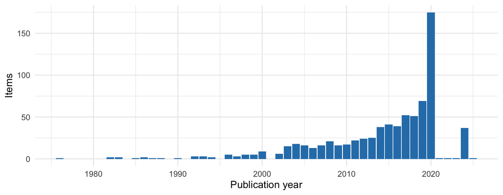

### Types of items

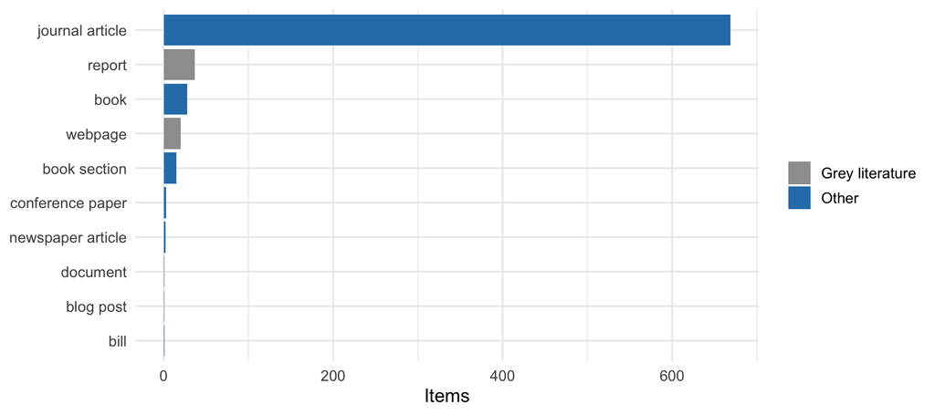

### Open access

Open access status of the publications found in OpenAlex. *Gold* and *diamond*: open in an open access journal; *hybrid*: open in a subscription journal; *green*: an open copy is in a repository; *bronze*: free to read on the publisher’s site; *closed*: not openly available.

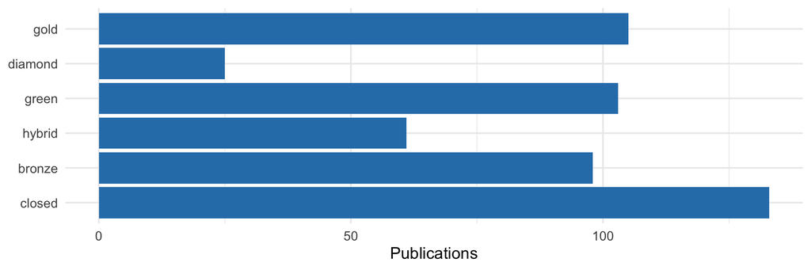

### Most frequent journals

| Journal | Items |
| --- | --- |
| Journal of Test Data | 37 |
| Science | 36 |
| Nature | 21 |
| Proceedings of the National Academy of Sciences | 19 |
| Emerging Infectious Diseases | 18 |
| EcoHealth | 16 |
| Biological Conservation | 15 |
| The Lancet | 15 |
| Conservation Biology | 11 |
| Philosophical Transactions of the Royal Society B: Biological Sciences | 11 |

### Countries of the authors

Number of publications with at least one author from the country, for the publications found in OpenAlex.

| Country | Publications |
| --- | --- |
| United States | 276 |
| United Kingdom | 160 |
| Australia | 65 |
| China | 60 |
| France | 52 |
| Germany | 43 |
| Canada | 40 |
| Brazil | 37 |
| Netherlands | 35 |
| Italy | 31 |
| Switzerland | 30 |
| Hong Kong SAR China | 22 |
| South Africa | 20 |
| Spain | 19 |
| Norway | 18 |

## How the checks work

**NoteDetails of the checks**

#### identifiers

##### DOI coverage (`met_id_doi`)

Number and share of items with a valid DOI, and items whose DOI field is filled but contains no valid DOI. DOIs are extracted with `openalexPro::extract_doi()` and lower cased.

##### ISBN coverage (`met_id_isbn`)

Number and share of items with an ISBN, overall and for the item types which should have one (`book`, `bookSection`).

##### ISSN coverage (`met_id_issn`)

Number and share of items with an ISSN, overall and for the item types which should have one (`journalArticle`, `magazineArticle`).

##### ISSN not in the standard form (`met_id_issn_form`)

Items whose ISSN field is not in the standard form: each ISSN as `1234-567X` (with hyphen, capital X), several separated by “,”. The ISSNs are checked with their check digit. If all are valid, the standard form is proposed; otherwise the item is listed with the ISSNs which are not valid.

##### DOIs in the wrong field (`met_id_doi_misplaced`)

Items with an empty DOI field but a DOI in the `Url` or `Extra` field. These DOIs are not used for the OpenAlex lookup and should be moved to the DOI field.

##### DOIs in the wrong form (`met_id_doi_form`)

Items whose DOI field contains a valid DOI, but not as a bare DOI: as a link (`https://doi.org/10.…`), with a prefix (`doi:`, `DOI`), URL-encoded (`%5B` for `[`) or with spaces or other characters around it. Citation styles add the link themselves, so a link in the DOI field appears twice in a bibliography. The bare DOI is the one recognised by `openalexPro::extract_doi()`, keeping its upper and lower case.

##### Items without identifier (`met_id_none`)

Items with none of DOI, ISBN, ISSN or Url. These items can neither be checked against OpenAlex nor easily be retrieved by readers.

##### DOIs found in OpenAlex for items without a DOI (`met_id_candidates`)

For items without a DOI, OpenAlex was searched by title (see [get_doi_candidates()]). The works found are compared with the item: title (ignoring case and punctuation), year and the surname of the first author. A work is a *likely* match if the titles are (nearly) the same (similarity at least 0.95), the years differ by at most 1 and the first authors have the same surname (year or author are not compared if the item has none), and the title has at least 4 words (short titles like “Zoonoses” are too general). It is a *possible* match if the titles are similar (at least 0.8). All likely and possible works with a DOI are kept, sorted per item, best first. DOIs used by another item in the group are noted (the item would be a duplicate).

#### metadata

##### Filled fields per item type (`met_meta_fields`)

Percentage of items with a filled field, per item type, for the main fields: Title, Author, Publication Year, Publication Title, Publisher, DOI, ISBN, ISSN, Url, Abstract Note and Language. Not every field is expected for every item type, e.g. reports have no Publication Title.

##### Problematic publication years (`met_meta_year`)

Items whose date is missing (`missing`), from whose date Zotero could not derive a year (`unparseable`), or whose year lies in the future (`future`).

##### Duplicate items (`met_meta_duplicates`)

Items which are in the group more than once, identified by the same DOI, or by the same normalised title (lower case, letters and digits only), publication year and first word of the first author.

##### Language not given as a standard code (`met_meta_language`)

Items whose language is not given as a standard language code, i.e. a two-letter ISO 639-1 code, optionally with a region (`en`, `en-US`), but e.g. as a name (`English`), a three-letter code (`eng`) or in a different spelling (`EN`, `en_us`). Citation styles and other tools only recognise the codes. Where the value is recognised, the standard code is proposed, based on the ISO 639-2 list (R package ISOcodes): codes, three-letter codes and the English names of the languages. Other values, e.g. names in the language itself, several languages or other text, are listed without a proposal.

#### openalex_check

##### Zotero DOIs found in OpenAlex (`met_check_found`)

Valid Zotero DOIs which were / were not found in OpenAlex. A DOI which is not found is either not indexed by OpenAlex or wrong.

##### Retracted works (`met_check_retracted`)

Works flagged as retracted by OpenAlex, with the key of the Zotero item(s) with the same DOI.

##### Wrong DOIs (`met_check_mismatch`)

Items whose DOI points in OpenAlex to a work with a different title or year, which usually means that the wrong DOI is attached to the item. An item is flagged when the title similarity (normalised Levenshtein distance) is below 0.8 or the years differ by more than one.

##### Item type agreement (`met_check_type`)

Zotero item type compared with the OpenAlex work type for items with the same DOI.

##### Missing dates found in OpenAlex (`met_check_date`)

Items without a date whose DOI was found in OpenAlex: the publication date in OpenAlex is proposed. OpenAlex gives 1 January when only the year is known, so such dates are proposed as the year only. Items whose DOI points to a different publication are left out.

##### Empty fields found in OpenAlex (`met_check_fill`)

Journal articles with an empty journal, volume, issue or pages field whose DOI was found in OpenAlex with these details: the values in OpenAlex are proposed. The journal is only taken if the publication is in a journal in OpenAlex (not e.g. a repository). Page ranges which end before they start (e.g. `1260-2`, shortened or wrong) are not proposed. Items whose DOI points to a different publication are left out.

##### OpenAlex ID in the Extra field (`met_check_openalex_id`)

Items whose DOI was found in OpenAlex, compared with the OpenAlex ID noted in their Extra field (a line `OpenAlex: W…`). Items without such a line can get it, which links them to OpenAlex for later checks. Items with a different ID are listed for checking: OpenAlex merges records, and the ID of a merged record redirects to the new one. Items whose DOI points to a different publication are left out.

##### OpenAlex ID in the Extra field not valid (`met_check_extra_id`)

Checks the lines `OpenAlex: …` in the Extra field (looked up by [get_extra_ids()]). A line is not valid if - it is not an OpenAlex work ID (`W` and digits), - the item has several lines with different IDs, - the ID is not in OpenAlex (wrong, or merged into another record), or - the work is a different publication: its DOI is not the DOI of the item, or, for items without DOI, its title is not similar (similarity below 0.8, see [title_similarity()]).

#### profile

##### Publication years (`met_prof_year`)

Number of items per publication year, with cumulative counts. Items without a year are counted as `NA`.

##### Open access status (`met_prof_oa`)

OpenAlex open access status (gold, diamond, green, hybrid, bronze, closed) of the works, overall and per publication year.

##### Top journals (`met_prof_journals`)

The 50 most frequent journals, from the Publication Title in Zotero and the source of the primary location in OpenAlex. Ties at rank 50 are included.

##### Author countries (`met_prof_countries`)

Number of works with at least one author affiliated with an institution in a country, per country (ISO 3166-1 alpha-2 codes from OpenAlex).

##### Item types and grey literature (`met_prof_types`)

Number of items per item type (Zotero) or work type (OpenAlex), and the share of grey literature, i.e. reports, theses, dissertations, web pages, documents, presentations, manuscripts, blog posts and preprints.

##### Languages (`met_prof_language`)

Languages as entered, and normalised to two letter codes (lower case, region removed, English spellings mapped to `en`). Inconsistent codes in the language as entered are a quality issue in themselves.

#### maintenance

##### Group activity (`met_maint_activity`)

Items added per month, and items added / modified in the 30 days before the metrics were calculated.

##### Items without tags (`met_maint_tags`)

Items without manual tags. Automatic tags, e.g. keywords imported from the publisher, are ignored.